# ManyBabies 1: Pilot Data Analysis

# 3 Condition differences

```r
diffs <- d %>%
  filter(trial_type != "Train",
         looking_time != 0,
         !is.na(looking_time)) %>%
  group_by(lab, subid, age_days, trial_num) %>%
  filter(sum(trial_type=="IDS") == 1 &
           sum(trial_type=="ADS") == 1) %>% # take only pairs that are complete
  summarise(diff = looking_time[trial_type=="IDS"] -
              looking_time[trial_type=="ADS"],
            diff_log = log10(looking_time[trial_type=="IDS"]) -
              log10(looking_time[trial_type=="ADS"]))
```

What’s the distributional form of these data?

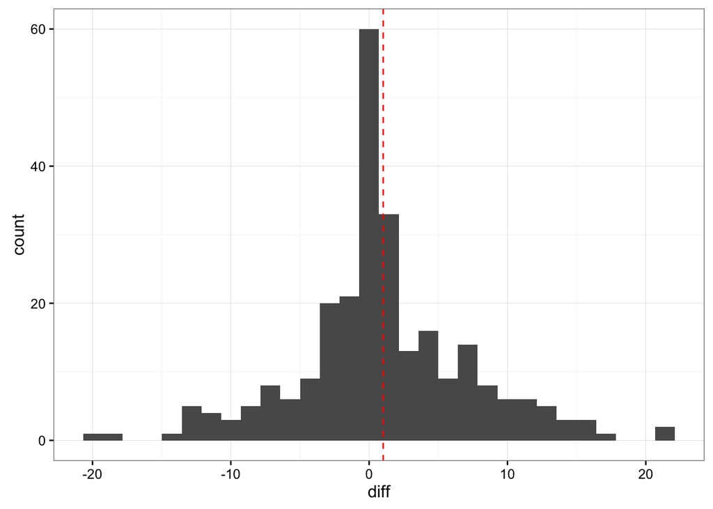

```r
qplot(diff, data = diffs) +
  geom_vline(xintercept = mean(diffs$diff), col = "red", lty = 2)
```

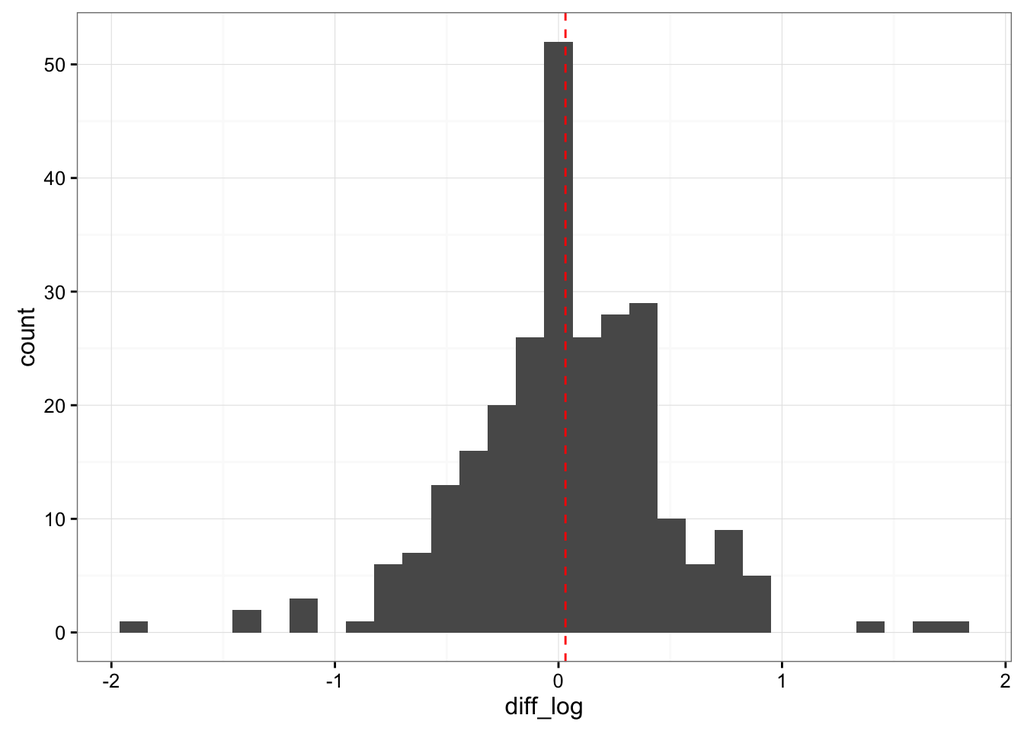

```r
qplot(diff_log, data = diffs) +
  geom_vline(xintercept = mean(diffs$diff_log), col = "red", lty = 2)
```

What’s the distributional form of these data? *Is the spike near 0.0 from the stanford 2s kids?*

[figure not shown]

```r
qplot(idspref, data = diffs)
```

How do they change with trials?

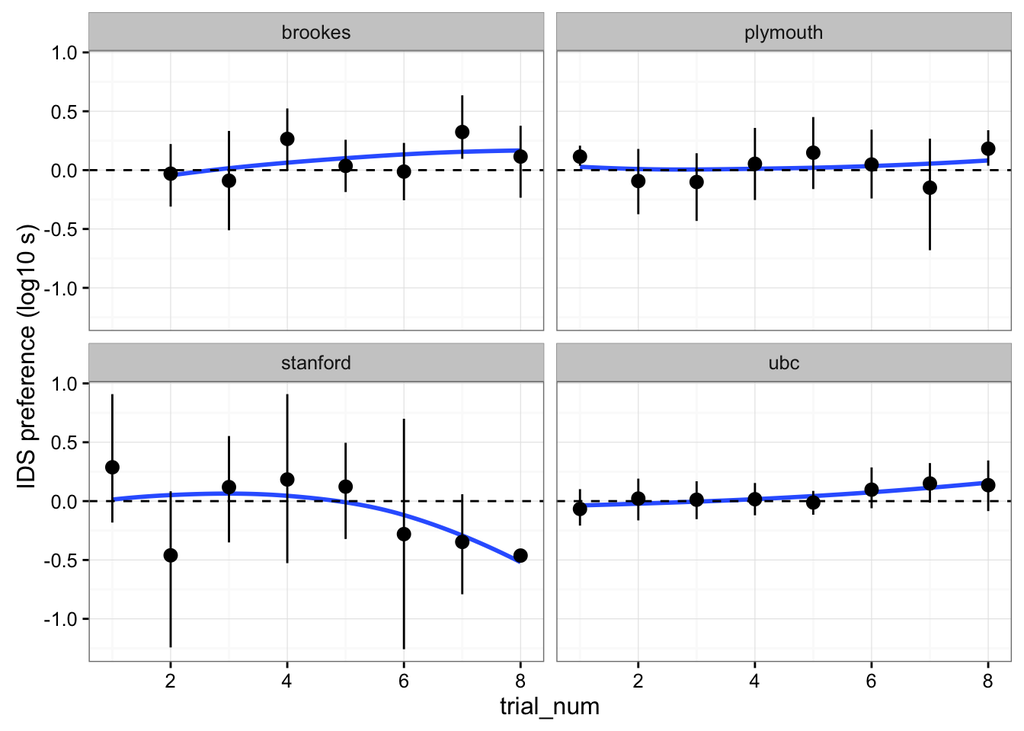

```r
ms_diff <- diffs %>%
  group_by(lab, trial_num) %>%
  multi_boot_standard(col = "diff_log", na.rm=TRUE)

ggplot(ms_diff, aes(x = trial_num, y = mean)) +
         geom_smooth(se = FALSE, span = 2) +
  facet_wrap(~lab) +
  geom_pointrange(aes(ymin = ci_lower, ymax = ci_upper),
                 position = position_dodge(width= .1)) +
  ylab("IDS preference (log10 s)") +
  geom_hline(yintercept = 0, lty = 2)
```

Or with age?

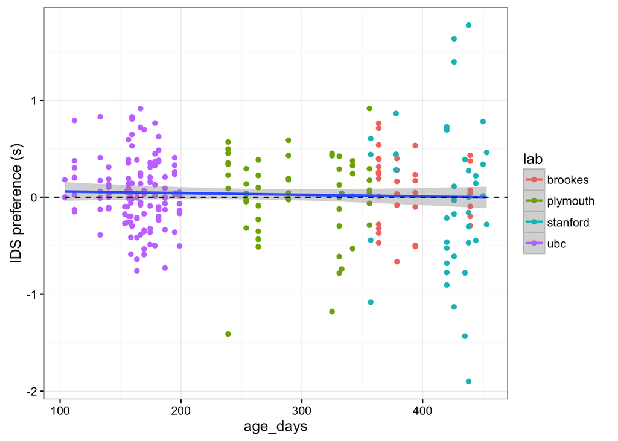

```r
qplot(age_days, diff_log, col = lab, group = 1, data = diffs) +
  geom_smooth(method = "lm") +
  geom_hline(yintercept = 0, lty = 2) +
  ylab("IDS preference (s)")
```

By age and by trial.

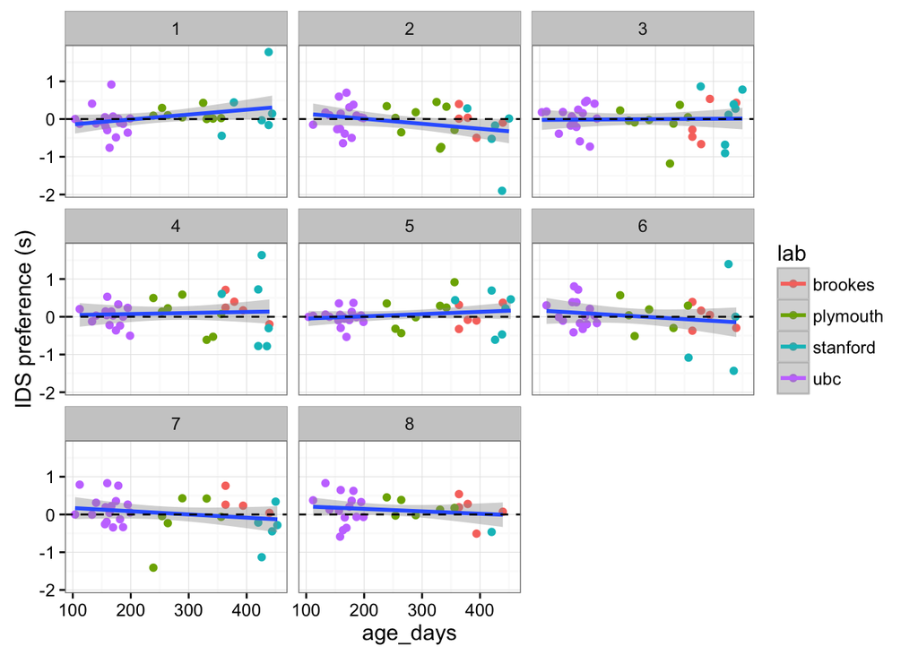

```r
qplot(age_days, diff_log, col = lab, group = 1, data = diffs) +
  geom_smooth(method = "lm") +
  facet_wrap(~trial_num) +
  geom_hline(yintercept = 0, lty = 2) +
  ylab("IDS preference (s)")
```

# 4 Hypothesis tests

**I would very much recommend including random effects of item, but that info is not included with the data as is.**

# 3 Hypothesis tests

**I would very much recommend including random effects of item, but that info is not included with the data as is.**  
*strong agree -mk*

*General question: is the goal of the analyses to (1) present what we believe to be the most appropriate analysis? (2) To reflect current practices? (3) to compare the two or (4) something else? -mk*

## 4.1 Overall preference tests

#### 4.1.0.1 One Sample t-test against chance

Using log transformed looking time.

```r
d_t_test1 <- d %>%
  filter(trial_type != "Train",
         looking_time != 0, !is.na(looking_time)) %>%
  mutate(log_lt = log(looking_time)) %>%
  group_by(subid,trial_type) %>%
  summarise(log_lt = mean(log_lt)) %>%
  group_by(subid) %>%
  filter(n() == 2) %>%
  summarize(log_lt_diff = log_lt[trial_type == "IDS"] - log_lt[trial_type == "ADS"])
t.test(d_t_test1$log_lt_diff , mu = 0)
```

```
##
##  One Sample t-test
##
## data:  d_t_test1$log_lt_diff
## t = -0.28991, df = 43, p-value = 0.7733
## alternative hypothesis: true mean is not equal to 0
## 95 percent confidence interval:
##  -0.1652252  0.1236923
## sample estimates:
##   mean of x
## -0.02076646
```

#### 4.1.0.2 Paired t-test

As above, but perhaps it is simpler to compare conditions, as our mixed effects models will use a condition predictor. Using log transformed looking time.

```r
d_t_test2 <- d %>%
  filter(trial_type != "Train",
         looking_time != 0, !is.na(looking_time)) %>%
  mutate(log_lt = log(looking_time)) %>%
  group_by(subid,trial_type) %>%
  summarise(log_lt = mean(log_lt))
t.test(log_lt ~  trial_type, data = d_t_test2, paired = T)
```

```
##
##  Paired t-test
##
## data:  log_lt by trial_type
## t = 0.28991, df = 43, p-value = 0.7733
## alternative hypothesis: true difference in means is not equal to 0
## 95 percent confidence interval:
##  -0.1236923  0.1652252
## sample estimates:
## mean of the differences
##              0.02076646
```

#### 3.1.0.3 Metaregression instead of t-test

```r
d_lmer0 <- d %>%
  filter(trial_type != "Train",
  looking_time != 0, !is.na(looking_time)) %>%
  mutate(log_lt = log(looking_time), AgeC = (age_days - mean(age_days))/sd(age_days)) %>%
  group_by(AgeC,subid,lab,trial_type) %>%
  summarize(log_lt = mean(log_lt)) %>%
  filter(n() == 2) %>%
  mutate(log_lt_diff = log_lt[trial_type == "IDS"] - log_lt[trial_type == "ADS"])

summary(lmer(log_lt_diff ~ 1 + (1|lab), data = d_lmer0))
```

[output not shown]

## 4.2 IDS Preference across age

#### 4.2.0.1 Linear effect of age

Planned regression: 1 + CentredAge * Trial Type + (1 + Centred Age * Trial Type)  
I removed the by lab interaction to aid convergence.

```r
summary(lmer(log_lt_diff ~ 1 + AgeC + (1+ AgeC |lab), data = d_lmer0))
```

[output not shown]

#### 4.2.0.2 Quadratic effect of age

Planned regression: 1 + (CentredAge + CentredAge^2) * Trial Type + (1 + (Centred Age + CentredAge ^2) * Trial Type)  
I removed the by lab interaction to aid convergence

```r
summary(lmer(log_lt_diff ~ 1 + poly(AgeC,2) + (1+ poly(AgeC,2) |lab), data = d_lmer0))
```

[output not shown]

#### 4.2.0.3 Secondary hypothesis tests, e.g trial order and age.

We will fit a linear mixed effects model predicting all individual observations, with the structure:  
log(looking.time) ~ trial.num * stimulus * age + (trial.num * stimulus | subid) + (trial.num * stimulus * age | lab)  
NB. This is taken from the RRR. Does stimulus here refer to condition or item? I have taken it to refer to condition.  
Interactions removed to aid convergence.

*mk: why not mixed effects structures in the other models as well? I think we have 3 sources of random variance we want to model here: random subids nested within random labs, and random stimuli (indivudal items).*

```r
d_lmer3 <- d %>%
  filter(trial_type != "Train",
         looking_time != 0, !is.na(looking_time)) %>%
  mutate(log_lt = log(looking_time), AgeC = (age_days - mean(age_days))/sd(age_days),trial_numC = (trial_num - mean(trial_num))/sd(trial_num))
summary(lmer(log_lt ~ 1 + AgeC * trial_type * trial_numC + (1+ trial_type + trial_numC|subid)+ (1+ AgeC + trial_type + trial_numC|lab) , data = d_lmer3))
```

```
## Linear mixed model fit by REML ['lmerMod']
## Formula: log_lt ~ 1 + AgeC * trial_type * trial_numC + (1 + trial_type +
##     trial_numC | subid) + (1 + AgeC + trial_type + trial_numC |      lab)
##    Data: d_lmer3
##
## REML criterion at convergence: 1652.6
##
## Scaled residuals:
##     Min      1Q  Median      3Q     Max
## -4.4142 -0.5072  0.0854  0.6028  3.4941
##
## Random effects:
##  Groups   Name          Variance  Std.Dev. Corr
##  subid    (Intercept)   0.3611772 0.6010
##           trial_typeIDS 0.0195230 0.1397    0.89
##           trial_numC    0.0984341 0.3137   -0.23  0.24
##  lab      (Intercept)   1.8648268 1.3656
##           AgeC          0.1136362 0.3371   -1.00
##           trial_typeIDS 0.0152951 0.1237    1.00 -1.00
##           trial_numC    0.0008011 0.0283   -1.00  1.00 -1.00
##  Residual               0.6658213 0.8160
## Number of obs: 609, groups:  subid, 44; lab, 4
##
## Fixed effects:
##                                Estimate Std. Error t value
## (Intercept)                    1.237664   0.727179   1.702
## AgeC                          -0.101667   0.383803  -0.265
## trial_typeIDS                 -0.004912   0.094432  -0.052
## trial_numC                    -0.170926   0.069160  -2.471
## AgeC:trial_typeIDS            -0.052317   0.075860  -0.690
## AgeC:trial_numC                0.016672   0.066290   0.252
## trial_typeIDS:trial_numC       0.029063   0.067137   0.433
## AgeC:trial_typeIDS:trial_numC -0.088794   0.068049  -1.305
##
## Correlation of Fixed Effects:
##             (Intr) AgeC   tr_IDS trl_nC AgC:_IDS AgC:_C t_IDS:
## AgeC        -0.682
## tril_typIDS  0.653 -0.408
## trial_numC  -0.224  0.136 -0.093
## AgC:trl_IDS -0.119  0.307 -0.046 -0.008
## AgC:trl_nmC  0.036 -0.122 -0.007 -0.062  0.022
## trl_tIDS:_C -0.001  0.000  0.002 -0.449  0.065    0.017
## AgC:_IDS:_C -0.004  0.006  0.050  0.018  0.016   -0.460  0.041
```

## 4.3 Christina’s Planned Moderator analyses

These analyses were planned to be by preference score, rather than by interactions. **Iff we are able to include item names in the data files, I would suggest going by interactions instead so that we can account for item effects with regard to, e.g., missing data.**

## 3.3 Christina’s Planned Moderator analyses

These analyses were planned to be by preference score, rather than by interactions. **Iff we are able to include item names in the data files, I would suggest going by interactions instead so that we can account for item effects with regard to, e.g., missing data.** *cant we measure item effeects on preference scores too, since the items are paired across condition? -mk*

#### 4.3.0.1 Preference by method

```r
d_moder1 <- d %>%
  filter(trial_type != "Train",
         looking_time != 0, !is.na(looking_time)) %>%
  mutate(log_lt = log(looking_time),AgeC = (age_days - mean(age_days))/sd(age_days)) %>%
  group_by(subid,trial_type,method,lab,AgeC) %>%
  summarise(log_lt = mean(log_lt)) %>%
  group_by(subid,method,lab,AgeC) %>%
  filter(n() == 2) %>%
  summarize(log_lt_diff = log_lt[trial_type == "IDS"] - log_lt[trial_type == "ADS"])

summary(lmer(log_lt_diff ~ method + (1|lab), data = d_moder1))
```

```
## Linear mixed model fit by REML ['lmerMod']
## Formula: log_lt_diff ~ method + (1 | lab)
##    Data: d_moder1
##
## REML criterion at convergence: 63
##
## Scaled residuals:
##      Min       1Q   Median       3Q      Max
## -2.82911 -0.73116  0.08235  0.75704  1.86787
##
## Random effects:
##  Groups   Name        Variance Std.Dev.
##  lab      (Intercept) 0.000    0.0000
##  Residual             0.225    0.4744
## Number of obs: 44, groups:  lab, 4
##
## Fixed effects:
##                     Estimate Std. Error t value
## (Intercept)          -0.1986     0.1430  -1.389
## methodHPP             0.1987     0.2132   0.932
## methodsingle-screen   0.2515     0.1727   1.456
##
## Correlation of Fixed Effects:
##             (Intr) mthHPP
## methodHPP   -0.671
## mthdsngl-sc -0.828  0.555
```

#### 4.3.0.2 Preference by method interacting with age

Note that this analysis is perfectly confounded with lab at the moment, so it will not converge.  
ids.pref ~ method * age + (1 +age | lab)

```r
summary(lmer(log_lt_diff ~ method*AgeC + (1+AgeC|lab), data = d_moder1))
```

```
## Linear mixed model fit by REML ['lmerMod']
## Formula: log_lt_diff ~ method * AgeC + (1 + AgeC | lab)
##    Data: d_moder1
##
## REML criterion at convergence: 64
##
## Scaled residuals:
##      Min       1Q   Median       3Q      Max
## -2.78217 -0.65459  0.00365  0.72249  1.91850
##
## Random effects:
##  Groups   Name        Variance Std.Dev. Corr
##  lab      (Intercept) 0.28321  0.5322
##           AgeC        0.07671  0.2770   -1.00
##  Residual             0.23685  0.4867
## Number of obs: 44, groups:  lab, 4
##
## Fixed effects:
##                          Estimate Std. Error t value
## (Intercept)               -0.3600     0.9628  -0.374
## methodHPP                  0.4111     1.1206   0.367
## methodsingle-screen        0.5106     1.0567   0.483
## AgeC                       0.1172     0.6361   0.184
## methodHPP:AgeC            -0.2826     0.8267  -0.342
## methodsingle-screen:AgeC  -0.3770     0.7318  -0.515
##
## Correlation of Fixed Effects:
##             (Intr) mthHPP mthds- AgeC   mHPP:A
## methodHPP   -0.859
## mthdsngl-sc -0.911  0.783
## AgeC        -0.978  0.841  0.891
## mthdHPP:AgC  0.753 -0.873 -0.686 -0.769
## mthdsng-:AC  0.850 -0.731 -0.928 -0.869  0.669
```

## 3.4 Melissa’s planned ‘analysis flexiblity’ analysis

The general idea/approach is to specify a generative model of data inclusion (e.g. select subids to include, trials to include, lt windows to analyze), data analysis (preference vs. difference-from-chance, t test, etc., more things I haven’t thought of), and optional stopping, and then to do some simulations of fitting this model to each lab maximizing effect size (essentially simulating ‘worst case’, intentional p-hacking) as well as some more limited models that e.g. select windows of analysis after data collection, stop early, drop participants, etc in a less nefarious way.

If we have interesting moderator findings, it would also be nice to see e.g. what kinds of sensible measurements you can make on standardized large datasets that you might **not** be able to do on heterogeneous data

# 5 Conclusions

Practical recommendations:

- Need to make standardized templates for `lab`, `subject`, and `trial` data.
- Need to develop policies for data exclusion at the subject level (e.g., any child excluded)
- Need to walk through and select the planned analyses - this is going to be tricky!